# Mapping KEGG pathways to proteins

07 April, 2020

## Investigating protein allocation in *Ralstonia eutropha* H16

The *Ralstonia eutropha* H16 genome was previously annotated using the EMBL-maintained tool [eggNOG](http://eggnogdb.embl.de/#/app/home), see my R notebook `../Ralstonia_COG/Ralstonia_H16_genome_re_annotation.Rmd`. All genes/proteins were annotated based on sequence similarity and grouped into homology groups (Cluster of Orthologous Groups, COG). Groups were then manually curated by moving genes from less to better matching categories.

However, one important difference between COG and KEGG is that KEGG Brite annotation is not unambiguous like COG, but one gene/protein can be mapped to multiple functions/pathways. This behavior is more realistic then the COG classification. Another advantage is that KEGG is a manually curated, systematic, and well-connected database. Every protein in KEGG is associuated with enzyme-EC numbers, GO terms, pathways, and associated enzymatic reactions. This makes KEGG pathways superior to COG terms when it comes to funtional interpretation or quantitative metabolic models.

In this notebook I will try to map KEGG pathways (Brite or Modules) to the *R. eutropha* proteome and deal with ambiguous protein annotation. Sources that I use are:

- Previously expanded *R. eutropha* annotation based on COG ([eggNOG](http://eggnogdb.embl.de/#/app/home), downloaded 2019-06-12)
- [KEGG BRite](https://www.kegg.jp/kegg-bin/show_organism?org=reh) database for *R. eutropha* H16 (downloaded 2018-09-10)

## Problem definition

1. Map proteins to KEGG pathways, either ‘Brite’ hierarchy or ‘Modules’
2. Investigate predicted protein abundance range per pathway (min, mean, max)
3. Try to formalize biological role of pathways: size, reactions, input, output, variability

## Task 1: Map proteins to KEGG pathways

We begin with elucidating differences between KEGG Brite and KEGG Modules. Are they the same (apparently not), which one is more comprehensive or has higher coverage for *R. eutropha*?

```r
# load packages
library(tidyverse)
library(lattice)
library(latticeExtra)
library(Rtools)
library(stringr)
library(graph)
library(igraph)
library(KEGGREST)
library(KEGGgraph)
```

Several alternatives are available to download and/or parse KEGG xml files, among them the R `KEGGREST` or the `KEGGgraph` package. One can also use simple bash download from KEGG using their REST API (thanks Johannes Asplund-Samuelsson for simple example).

```r
wget -qO - http://rest.kegg.jp/link/ko/ko01200
```

We can also import KEGG files directly into R data frames or lists using the KEGGREST package which provides an R interface for the KEGG API.

```r
# KEGG Brite annotation file, manually parsed from website
reh_brite <- read_csv("../data/KEGG_Brite_20180910_reh00001.csv")
head(reh_brite)
```

| System | Process | Pathway | Protein | short_name | full_name | EC-class |
| --- | --- | --- | --- | --- | --- | --- |
| Metabolism | Carbohydrate metabolism | Glycolysis / Gluconeogenesis | H16_B2564 | glk | Glucokinase | K00845 glk; glucokinase |
| Metabolism | Carbohydrate metabolism | Glycolysis / Gluconeogenesis | H16_A1502 | pgi1 | Glucose-6-phosphate isomerase | K01810 GPI; glucose-6-phosphate isomerase |
| Metabolism | Carbohydrate metabolism | Glycolysis / Gluconeogenesis | H16_B1502 | pgi2 | Glucose-6-phosphate isomerase | K01810 GPI; glucose-6-phosphate isomerase |
| Metabolism | Carbohydrate metabolism | Glycolysis / Gluconeogenesis | H16_A0999 | fbp | Fructose-1,6-bisphosphatase | K03841 FBP; fructose-1,6-bisphosphatase I |
| Metabolism | Carbohydrate metabolism | Glycolysis / Gluconeogenesis | PHG422 | cbbFp | fructose-1,6-bisphosphate | K01086 fbp-SEBP; fructose-1,6-bisphosphatase I / sedoheptulose-1,7-bisphosphatase |
| Metabolism | Carbohydrate metabolism | Glycolysis / Gluconeogenesis | H16_B1390 | cbbF2 | Fructose-1,6-/sedoheptulose-1,7-bisphosphatase | K01086 fbp-SEBP; fructose-1,6-bisphosphatase I / sedoheptulose-1,7-bisphosphatase |

```r
# Alternatives
# ---------------
#
# KEGGREST package as interface to KEGG
# download annotation for all Ralstonia eutropha genes

# examples to query a single gene ID, KO number, module, or pathway
#keggGet("reh:H16_A0003") %>% head
#keggGet("K00847") %>% {.[[1]][1:5]} %>% head
#keggGet("M00432") %>% flatten
#keggGet("reh00010") %>% head

# obtain mapping of modules for each gene
reh_modules <- keggLink("module", "reh") %>%
  enframe(name = "gene", value = "module")

# obtain mapping of modules for each gene
reh_pathways <- keggLink("pathway", "reh") %>%
  enframe(name = "gene", value = "pathway")

# How many unique genes or modules in R.e.?
paste(
  reh_modules %>% pull(gene) %>% unique %>% length, "genes annotated in",
  reh_modules %>% pull(module) %>% unique %>% length, "modules"
)
```

```
[1] "835 genes annotated in 191 modules"
```

```r
# How many unique genes or pathways in R.e.?
paste(
  reh_pathways %>% pull(gene) %>% unique %>% length, "genes annotated in",
  reh_pathways %>% pull(pathway) %>% unique %>% length, "pathways"
)
```

```
[1] "2047 genes annotated in 128 pathways"
```

```r
# compared to KEGG Brite, downloaded manually
paste(
  reh_brite %>% pull(Protein) %>% unique %>% length, "genes annotated in",
  reh_brite %>% pull(Pathway) %>% unique %>% length, "KEGG Brite pathways"
)
```

```
[1] "3362 genes annotated in 182 KEGG Brite pathways"
```

### Mapping genes expression to KEGG pathways

KEGG Modules are computationally generated units of KEGG pathways, while the latter are manually constructed. For now, the KEGG DB contains many more gene mappings for pathways then modules, which makes pathways the more promising and more complete base for construction of a coarse-grained model. We continue with exploration of KEGG pathways by adding Pathway names and meta data to the data frame. The final goal is to map gene expression quantifications to pathways and explore how many resources are invested per pathway, and how resource allocation changes over conditions. First, some pathways are removed as they are only overview ‘maps’.

```r
# some pathways are overview pathways that don't add any information
# (aggregates of several pathways):
# 01100 - Metabolic pathways
# 01110 - Biosynthesis of secondary metabolites
# 01120 - Microbial metabolism in diverse environments
# 01130 - Biosynthesis of antibiotics
# 01200 - Carbon metabolism
# 01210 - 2-Oxocarboxylic acid metabolism
# 01212 - Fatty acid metabolism
# 01230 - Biosynthesis of amino acids
# 01220 - Degradation of aromatic compounds
reh_pathways <- reh_pathways %>%
  filter(!grepl("01(100|110|120|130|200|210|212|220|230)", pathway))

# check how many unique genes remain in data
reh_pathways %>% pull(gene) %>% unique %>% length
```

```
[1] 2035
```

### Pathway network topology

To retrieve the topology of the network, we can use the KEGGgraph package. First we download all KGML files for all pathways. These files contain all nodes (enzymes) and edges (reactions/metabolites) of a metabolic network.

```r
# download KGML files for all pathways
for (pw in unique(reh_pathways$pathway)) {
  pw <- gsub("path:", "", pw)
  retrieveKGML(pw, organism = "reh", destfile = paste0("../KGML/", pw, ".kgml"))
}
```

The next step is to parse the graphs into an R graph or data frame object. Of these two different possibilities, a graph is probably the better option as it allows to use other graph based functions. We consctruct two helper functions, one that parses KGML files using KEGGgraph functions and stores results in a list; And a second that extracts the names of adjacent pathways that a pathway is connected to, in order to make a new coarse-grained, simplified network of all pathways. A third function retrieves KEGG pathway annotation using KEGGREST and returns a list.

```r
# function to parse all graphs from KGML files and store result in list
parse_KGML_list <- function(file_list) {
  graphs <- lapply(
    file_list,
    function(x) {
      parseKGML2Graph(
        file = x,
        expandGenes = TRUE,
        genesOnly = FALSE
      )
    }
  )
  names(graphs) <- paste0(
    "path:",
    stringr::str_extract(
      file_list, "[a-z]{3}[0-9]*"
    )
  )
  graphs
}

# function to retrieve all other pathways that a pathway is connected to.
# the only required argument is a list of pathways represented
# as graph (actually graphNEL) object
get_adjacent_pathways <- function(pathway_graphs) {
  lapply(1:length(pathway_graphs),
    function(i) {
      pws <- grep("path:", nodes(pathway_graphs[[i]]), value = TRUE)
      data.frame(
        stringsAsFactors = FALSE,
        from = rep(names(pathway_graphs)[[i]], length(pws)),
        to = pws
      ) %>% filter(
        !to == from,
        !grepl(":map", to),
        !grepl(":map", from)
      )
    }
  ) %>% bind_rows
}

# function to retrieve pathway metadata from KEGG
# for arbitrary pathways (by name) and store results
# in list
get_pathway_metadata <- function(pathway_list) {
  res <- lapply(pathway_list, function(x) {
    KEGGREST::keggGet(x)[[1]]
  })
  names(res) <- pathway_list
  res
}
```

[output not shown]

```r
reh_pathways_connections <- get_adjacent_pathways(reh_pathways_as_graph)
head(reh_pathways_connections)
```

We can construct a new graph from the list of edges/connections and plot the network using igraph/tidygraph packages. The input are two lists or data frames, ‘nodes’ with unique name and ID of genes and ‘edges’ indicating all recorded connections between nodes; However, the information in ‘edges’ already contains all possible nodes, so ‘edges’ alone can be sufficient. Node metadata can be stored in an extra data.frame (slot of the igraph object)

```r
# load additional libraries
library(tidygraph)
library(ggplot2)
library(ggraph)

# make a data.frame with node metadata, handy for creating the graph
reh_pathways_nodes <- reh_pathways %>%
  filter(pathway %in% reh_pathways_nodes) %>%
  group_by(pathway) %>%
  summarize(number_of_genes = length(gene)) %>%
  left_join(.,
    reh_pathways_connections$from %>%
      table %>% as.list %>% unlist %>%
      enframe("pathway", "interactions")
  ) %>%
  left_join(.,
    lapply(reh_pathway_meta, function(x) {
      data.frame(
        stringsAsFactors = FALSE,
        pathway = paste0("path:", unname(x$ENTRY)),
        pathway_name = x$NAME,
        pathway_map = x$PATHWAY_MAP,
        pathway_map_short = gsub(" biosynthesis| metabolism", "", x$PATHWAY_MAP),
        pathway_class = x$CLASS
      )
    }) %>% bind_rows
  )

head(reh_pathways_nodes)

# construct a new graph object from of pathway nodes/edges
reh_pathways_igraph <- tbl_graph(
  edges = reh_pathways_connections,
  nodes = rename(reh_pathways_nodes, name = pathway)
)
```

Plot the graph.

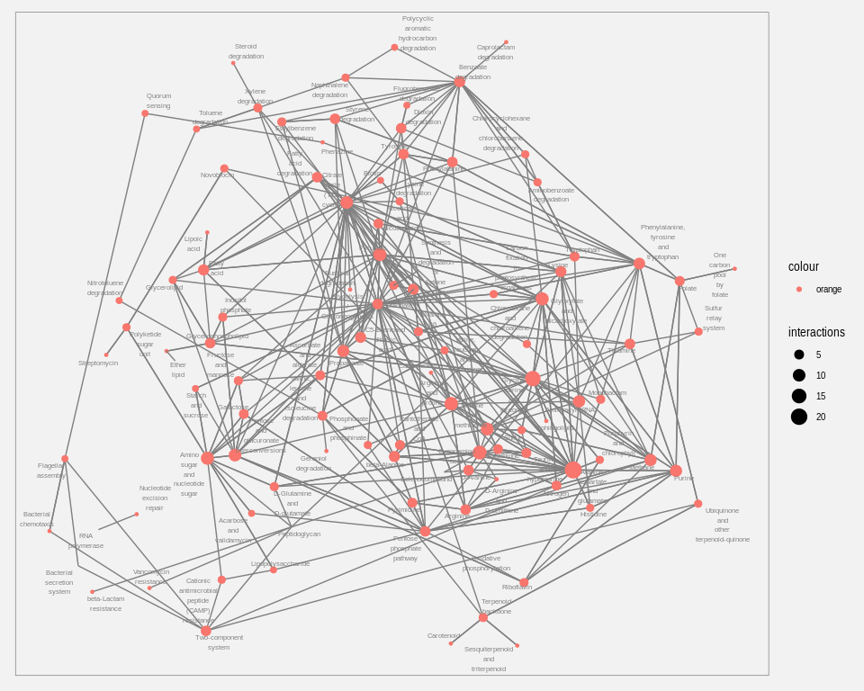

```r
# the layout argument takes one of: 'nicely', 'star', 'circle', 'gem', 'dh',
# 'randomly', 'fr', 'kk', 'drl', 'lgl', 'graphopt', 'grid', 'mds'
reh_pathways_plot <- ggraph(reh_pathways_igraph, layout = 'dh') +
geom_edge_link(colour = grey(0.5)) +
geom_node_point(aes(colour = "orange", size = interactions)) +
geom_node_text(aes(label = pathway_map_short %>% gsub(" ", "\n", .)), repel = TRUE, col = grey(0.5), size = 2) +
theme_graph(background = grey(0.95), foreground = grey(0.5),
  plot_margin = margin(10, 10, 10, 10))
print(reh_pathways_plot)
```